# CMSC320 Final Project

*By: Josh Widenhofer, Morein Ibrahim, Eshaan Nair, and Benjamin Jo*

# Introduction

The purpose of this model is to walk users through the data science pipeline. Our group decided to use the Campaign Finance Data from the Federal Election Committee. The reason why we decided to go with this dataset is because we would like to see if contributions toward each political party will have impact on democracy. Campaign finance is a crucial part of modern democratic systems, and analyzing the flow of money in elections allows us to understand political power dynamics. The FEC dataset can show how money influences elections, policy decisions, and who gets elected. This makes it highly relevant for anyone interested in political science, public policy, or the intersection of money and politics.

Three (potential) questions posed:

1. Does a shorter first name lead to an increase in disbursements?
2. Is there is a difference in the significance of the total disimbursements and political party that the disimbursements were contributed to?
3. Do donations in non-election years predict success during elections?

We are answering those questions because it can shed light on the impact of money on the political process, which is central to understanding democracy and fairness in the system. Additioanlly, answering these questions can help assess whether some groups or individuals have more influence than others due to their financial contributions, which speaks to issues of equity and access in the political process. Finally, by identifying patterns and trends in campaign finance, you can predict how future elections might be shaped by money. This is valuable for both political analysts and future candidates seeking to understand where they should focus their fundraising efforts.

## Data Preprocessing

The first thing we need to do is import the proper libraries, and then import, parse and organize our databases. Next, we needed access to the OpenFEC API in order to retrieve our data, so we applied for free key which was granted within minutes. At this stage, we wanted to ensure that our calls were actually retrieving data, so we created some generic parameters in order to retrieve a single page of data from the candidates/totals endpoint. This API call retrieves many features, however the features we will primarily use are 'name', 'cycle' and 'disbursements'

```python
from os import defpath
import pandas as pd
import requests as req
import matplotlib.pyplot as plt
import seaborn as sns



# Your API key
api_key = 'GNcf05H6SPmzJBWXzh7q4F5A3aFS5fu9Mm9fS2MQ'

# Base URL of the FEC API
base_url = 'https://api.open.fec.gov/v1/'

# Endpoint you want to access
endpoint = 'candidates/totals'

# Parameters for the API call
params1 = {
    'api_key': api_key,
    #'office': 'P',  # Example parameter for filtering presidential candidates
    #'cycle': 2016,
    'election_year': [2014,2016],
    'min_disbursements': 1,
    'page': 1,
    'per_page': 100,
}

# Making the GET request
response = req.get(base_url + endpoint, params=params1)

#ALL df fields: ['active_through', 'address_city', 'address_state', 'address_street_1', 'address_street_2',
#'address_zip', 'candidate_election_year', 'candidate_id', 'candidate_inactive', 'candidate_status',
#'cash_on_hand_end_period', 'coverage_end_date', 'coverage_start_date', 'cycle', 'cycles', 'debts_owed_by_committee',
#'disbursements', 'district', 'district_number', 'election_districts', 'election_year', 'election_years', 'federal_funds_flag',
#'first_file_date', 'has_raised_funds', 'incumbent_challenge', 'incumbent_challenge_full', 'individual_itemized_contributions',
#'is_election', 'last_f2_date', 'last_file_date', 'load_date', 'name', 'office', 'office_full', 'other_political_committee_contributions',
#'party', 'party_full', 'receipts', 'state', 'state_full', 'transfers_from_other_authorized_committee', 'two_year_period']

# Checking if the request was successful
if response.status_code == 200:
    data = response.json()
    df = pd.DataFrame(data['results'])
    df1 = df[['address_zip', 'is_election', 'candidate_id', 'cash_on_hand_end_period', 'coverage_end_date', 'coverage_start_date', 'cycle', 'disbursements', 'district', 'election_year', 'first_file_date', 'incumbent_challenge', 'individual_itemized_contributions', 'last_f2_date', 'last_file_date', 'load_date', 'name', 'office', 'other_political_committee_contributions', 'party', 'receipts', 'state', 'transfers_from_other_authorized_committee', 'two_year_period']]
    simple_df = df[['name', 'cycle', 'disbursements', 'receipts', 'cash_on_hand_end_period','office', 'state','is_election', 'candidate_status']].sort_values(by='name')
    df.to_csv('testfile.csv', index=False)


else:
    print(f'Error: {response.status_code}')

simple_df
```

|  | name | cycle | disbursements | receipts | cash_on_hand_end_period | office | state | is_election | candidate_status |
| --- | --- | --- | --- | --- | --- | --- | --- | --- | --- |
| 86 | ADESHINA, YINKA ABOSEDE | 2016 | 44540.00 | 45540.00 | 1000.00 | P | US | True | C |
| 1 | BARKSDALE, JAMES FREEMAN | 2016 | 4074479.00 | 2921085.00 | 9443.00 | S | GA | True | C |
| 44 | BEITIKS, MIKELIS VALAINIS | 2016 | 6498.00 | 6500.00 | 0.00 | S | CA | True | C |
| 36 | BERUFF, CARLOS | 2016 | 8724423.00 | 8724426.00 | 0.98 | S | FL | True | C |
| 13 | BICKELMEYER, MICHAEL | 2016 | 1573.00 | 1605.00 | 10.00 | S | OH | True | N |
| ... | ... | ... | ... | ... | ... | ... | ... | ... | ... |
| 40 | WILLIAMS, LILY TANG | 2016 | 19788.00 | 19789.00 | 0.00 | S | CO | True | C |
| 15 | WILSON, ROBIN LAVERNE | 2016 | 6819.00 | 8489.00 | 1668.00 | S | NY | True | C |
| 81 | WILSON, WILLIE | 2016 | 1100421.65 | 1100421.65 | 0.00 | P | US | True | C |
| 79 | WINSLOW, BRAD MR. | 2016 | 13028.29 | 30.00 | 1.00 | P | US | True | C |
| 33 | ZIRKELBACH, RAY | 2016 | 3839.78 | 3839.00 | 0.00 | S | IA | True | N |

100 rows × 9 columns

Now that we know we have access to the API, it's time to retrieve our data. Each API call retrieves a maximum of 100 results per page, and can call up to 120 times a minute. We store this data in an array of json objects.

```python
#Before, we only got one page of data.
params1 = {
    'api_key': api_key,
    #'office': 'P',  # Example parameter for filtering presidential candidates
    #'cycle': 2016,
    'election_year': [2014,2016],
    'min_disbursements': 1,
    'page': 1,
    'per_page': 100,
}

all_data = []
page = 1
#We only get 120 requests/min with the api key
while page < 120:
    params1['page'] = page
    response = req.get(base_url + endpoint, params=params1)
    if response.status_code != 200:
        break

    data = response.json()
    all_data.extend(data['results'])  # Assuming 'results' is where the data is stored


    page += 1

print(len(all_data), "entries retrieved.")
```

[output not shown]

Now that all the data is in a json file, we convert it into a pandas dataframe. However, there's still a lot of irrelevant features, so we trim them down to the identifying markers of name, office, state, and party. Disbursements, which is a fancy word for 'payments', is also a key feature that we must include.

```python
#Now with the json data stored in all_data, we'll put it in a df
df = pd.DataFrame(all_data)

df_old = df[['name', 'cycle', 'disbursements', 'office', 'state','party', 'candidate_id']].sort_values(by=['state'])
df_2012 = df_old
df_old
#df_2012.to_csv('2010s_data.csv', index=False)
```

|  | name | cycle | disbursements | office | state | party | candidate_id |
| --- | --- | --- | --- | --- | --- | --- | --- |
| 3252 | MOORE, MATTHEW EDWARD | 2014 | 60679.50 | H | AK | DEM | H2AK00101 |
| 657 | YOUNG, DONALD E | 2016 | 1322055.12 | H | AK | REP | H6AK00045 |
| 649 | MURKOWSKI, LISA | 2016 | 7167502.57 | S | AK | REP | S4AK00099 |
| 1425 | MILLER, JOSEPH W | 2016 | 411184.00 | S | AK | LIB | S0AK00121 |
| 1431 | MURKOWSKI, LISA | 2016 | 7167502.57 | S | AK | REP | S4AK00099 |
| ... | ... | ... | ... | ... | ... | ... | ... |
| 2152 | HARDY, CHARLES E | 2014 | 88284.00 | S | WY | DEM | S4WY00097 |
| 1411 | KONSMO, MICHAEL MR. | 2016 | 17002.10 | H | WY | REP | H6WY00134 |
| 2151 | CHENEY, ELIZABETH (LIZ) | 2014 | 1811475.00 | S | WY | REP | S4WY00089 |
| 1542 | CHRISTENSEN, LELAND G | 2016 | 164726.93 | H | WY | REP | H6WY00142 |
| 284 | CUMMINGS, DANIEL CLYDE | 2016 | 571.00 | H | WY | CON | H2WY00133 |

3489 rows × 7 columns

```python
# File paths for the 2014 and 2016 election data
file_2014 = 'federalelections2014.xls'
file_2016 = 'federalelections2016.xlsx'

# Sheets to load for each year
sheets_2014 = ['2014 US House Results by State', '2014 US Senate Results by State']
sheets_2016 = ['2016 US House Results by State', '2016 US Senate Results by State', '2016 Pres General Results']

# Dictionary to store DataFrames
dfs = {}

# Load the 2014 sheets
for sheet in sheets_2014:
    df = pd.read_excel(file_2014, sheet_name=sheet)
    dfs[sheet] = df

# Load the 2016 sheets
for sheet in sheets_2016:
    df = pd.read_excel(file_2016, sheet_name=sheet)
    dfs[sheet] = df
```

Now, we need to trim the data. Things that were trimmed: excessive rows, NaN's in the winner category are converted to L's. 'Scattered' is a name caused by an error in the government database. It can be assumed these are MAR, and will be removed

```python
# Function to trim DataFrame and replace null values
def trim_results(df, year):
    df_trimmed = df[['STATE ABBREVIATION', 'CANDIDATE NAME', 'GE WINNER INDICATOR']]
    df_trimmed.replace("NaN", pd.NA, inplace=True)
    df_trimmed['GE WINNER INDICATOR'].fillna('L', inplace=True)
    #df_trimmed = df_trimmed.dropna()
    df_trimmed.rename(columns={
        'STATE ABBREVIATION': 'state',
        'CANDIDATE NAME': 'name',
        'GE WINNER INDICATOR': 'winner'
    }, inplace=True)
    df_trimmed.dropna(subset=['name'], inplace=True)
    df_trimmed = df_trimmed[df_trimmed['name'] != 'Scattered']
    df_trimmed['cycle'] = year
    df_trimmed.reset_index(drop=True, inplace=True)
    # Capitalize 'name' column
    df_trimmed['name'] = df_trimmed['name'].str.upper()
    return df_trimmed

# Trim and replace for each DataFrame
df_2014_house_trimmed = trim_results(dfs['2014 US House Results by State'], 2014)
df_2014_senate_trimmed = trim_results(dfs['2014 US Senate Results by State'], 2014)
df_2016_house_trimmed = trim_results(dfs['2016 US House Results by State'], 2016)
df_2016_senate_trimmed = trim_results(dfs['2016 US Senate Results by State'], 2016)
```

[output not shown]

[output cut: 53 more lines]

[output not shown]

```python
df_2016_senate_trimmed
```

|  | state | name | winner | cycle |
| --- | --- | --- | --- | --- |
| 0 | AL | SHELBY, RICHARD C. | W | 2016 |
| 1 | AL | MCCONNELL, JONATHAN | L | 2016 |
| 2 | AL | MARTIN, JOHN | L | 2016 |
| 3 | AL | BOWMAN, MARCUS | L | 2016 |
| 4 | AL | MCGILL, SHADRACK | L | 2016 |
| ... | ... | ... | ... | ... |
| 396 | WI | JOHNSON, RON | W | 2016 |
| 397 | WI | FEINGOLD, RUSS | L | 2016 |
| 398 | WI | HARBACH, SCOTT | L | 2016 |
| 399 | WI | ANDERSON, PHILLIP N. | L | 2016 |
| 400 | WI | SCHIESS, JOHN | L | 2016 |

401 rows × 4 columns

Now, we will merge this with the original df to associate donations with winners.

```python
combined_df = pd.concat([df_2014_house_trimmed, df_2014_senate_trimmed, df_2016_house_trimmed, df_2016_senate_trimmed])

combined_df
```

|  | state | name | winner | cycle |
| --- | --- | --- | --- | --- |
| 0 | AL | BYRNE, BRADLEY | W | 2014 |
| 1 | AL | LEFLORE, BURTON R. | L | 2014 |
| 2 | AL | ROBY, MARTHA | W | 2014 |
| 3 | AL | WRIGHT, ERICK | L | 2014 |
| 4 | AL | ROGERS, MIKE | W | 2014 |
| ... | ... | ... | ... | ... |
| 396 | WI | JOHNSON, RON | W | 2016 |
| 397 | WI | FEINGOLD, RUSS | L | 2016 |
| 398 | WI | HARBACH, SCOTT | L | 2016 |
| 399 | WI | ANDERSON, PHILLIP N. | L | 2016 |
| 400 | WI | SCHIESS, JOHN | L | 2016 |

4966 rows × 4 columns

```python
merged_df = pd.merge(df_old, combined_df[['name', 'cycle', 'winner']], on=['name', 'cycle'], how='left')

merged_df.dropna(subset=['winner'], inplace=True)
merged_df.drop_duplicates(inplace=True)
merged_df.sort_values(by=['winner'], inplace=True)
merged_df.reset_index(drop=True, inplace=True)

merged_df
```

|  | name | cycle | disbursements | office | state | party | winner |
| --- | --- | --- | --- | --- | --- | --- | --- |
| 0 | CHRISTOPHER, WARREN | 2016 | 126045.81 | H | MD | DEM | L |
| 1 | OSBORN, SHANE | 2014 | 1996892.00 | S | NE | REP | L |
| 2 | GLASSHEIM, ELIOT | 2016 | 32793.00 | S | ND | DEM | L |
| 3 | GRAHAM, MALCOLM | 2016 | 104908.89 | H | NC | DEM | L |
| 4 | GRAHAM, MALCOLM | 2014 | 220684.44 | H | NC | DEM | L |
| ... | ... | ... | ... | ... | ... | ... | ... |
| 535 | CHABOT, STEVE | 2014 | 636368.81 | H | OH | REP | W |
| 536 | DESAULNIER, MARK | 2016 | 425816.84 | H | CA | DEM | W |
| 537 | JOHNSON, BILL | 2016 | 1350957.09 | H | OH | REP | W |
| 538 | RUPPERSBERGER, C.A. DUTCH | 2016 | 1150355.61 | H | MD | DEM | W |
| 539 | MURKOWSKI, LISA | 2016 | 7167502.57 | S | AK | REP | W |

540 rows × 7 columns

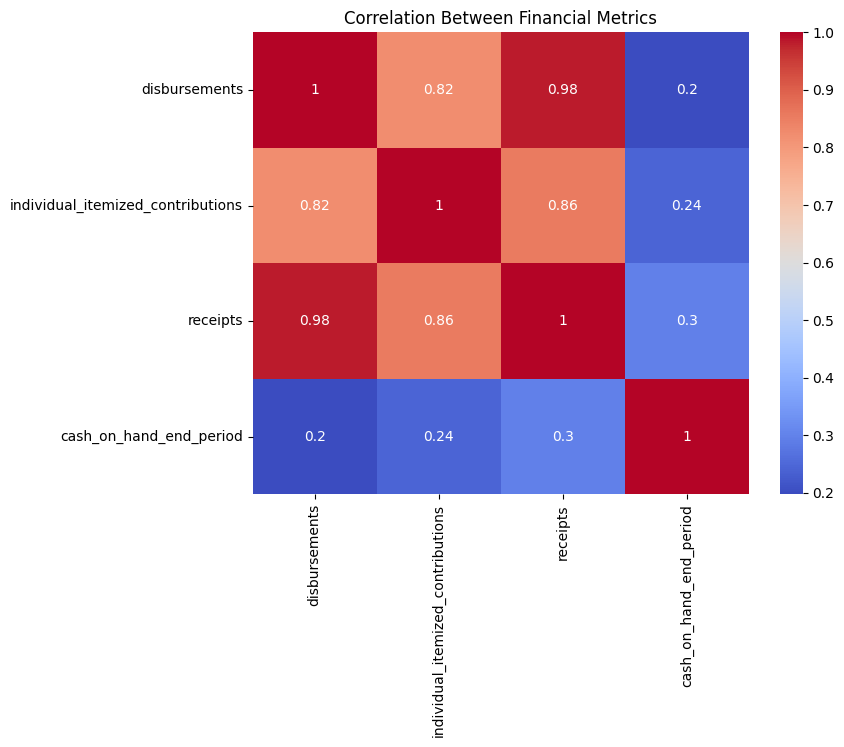

```python
correlation_matrix = df1[['disbursements', 'individual_itemized_contributions', 'receipts', 'cash_on_hand_end_period']].corr()
# Plotting correlation heatmap
plt.figure(figsize=(8,6))
sns.heatmap(correlation_matrix, annot=True, cmap='coolwarm')
plt.title('Correlation Between Financial Metrics')
plt.show()
```

Here is a coorelation graph between financial metrics. You can clearly see where there are coorelation between variables, red indicating a strong coorelation and blue indication little coorelation. A strong positive correlation between disbursements and individual itemized contributions could suggest that higher individual contributions lead to larger disbursements. Due to the high correlation, we will use the 'disbursements' feature as our main way of comparing campaign finances.

# Exploratory Data Analysis

```python
merged_df
```

|  | name | cycle | disbursements | office | state | party | winner |
| --- | --- | --- | --- | --- | --- | --- | --- |
| 0 | CHRISTOPHER, WARREN | 2016 | 126045.81 | H | MD | DEM | L |
| 1 | OSBORN, SHANE | 2014 | 1996892.00 | S | NE | REP | L |
| 2 | GLASSHEIM, ELIOT | 2016 | 32793.00 | S | ND | DEM | L |
| 3 | GRAHAM, MALCOLM | 2016 | 104908.89 | H | NC | DEM | L |
| 4 | GRAHAM, MALCOLM | 2014 | 220684.44 | H | NC | DEM | L |
| ... | ... | ... | ... | ... | ... | ... | ... |
| 535 | CHABOT, STEVE | 2014 | 636368.81 | H | OH | REP | W |
| 536 | DESAULNIER, MARK | 2016 | 425816.84 | H | CA | DEM | W |
| 537 | JOHNSON, BILL | 2016 | 1350957.09 | H | OH | REP | W |
| 538 | RUPPERSBERGER, C.A. DUTCH | 2016 | 1150355.61 | H | MD | DEM | W |
| 539 | MURKOWSKI, LISA | 2016 | 7167502.57 | S | AK | REP | W |

540 rows × 7 columns

Question 1: Does a shorter first name lead to an increase in disbursements?

First, we will trim the 'name' feature so that it is just the first name. Then, I will feed the features into an algorithm which should be able to make predictions on other years.

```python
merged_df['first_name'] = merged_df['name'].apply(lambda x: x.split(', ')[1])
merged_df['first_name_length'] = merged_df['first_name'].apply(len)
df1 = merged_df[['first_name_length', 'disbursements']]
df1
```

|  | first_name_length | disbursements |
| --- | --- | --- |
| 0 | 6 | 126045.81 |
| 1 | 5 | 1996892.00 |
| 2 | 5 | 32793.00 |
| 3 | 7 | 104908.89 |
| 4 | 7 | 220684.44 |
| ... | ... | ... |
| 535 | 5 | 636368.81 |
| 536 | 4 | 425816.84 |
| 537 | 4 | 1350957.09 |
| 538 | 10 | 1150355.61 |
| 539 | 4 | 7167502.57 |

540 rows × 2 columns

Now we split the data into training and testing sets

```python
from sklearn.model_selection import train_test_split

# Select features and target
X = df1[['first_name_length']]
y = df1['disbursements']

# Split the data into training and testing sets
X_train, X_test, y_train, y_test = train_test_split(X, y, test_size=0.2, random_state=42)

print("Training set size:", X_train.shape[0])
print("Test set size:", X_test.shape[0])
```

```
Training set size: 432
Test set size: 108
```

```python
from sklearn.linear_model import LinearRegression
from sklearn.metrics import mean_squared_error

# Initialize and train the model
model = LinearRegression()
model.fit(X_train, y_train)

# Make predictions on the test set
y_pred = model.predict(X_test)

# Evaluate the model
mse = mean_squared_error(y_test, y_pred)
print("Mean Squared Error:", mse)

# Display predictions vs actual values
comparison_df = pd.DataFrame({'Actual': y_test, 'Predicted': y_pred})
print(comparison_df)
```

```
Mean Squared Error: 2628024361317.308
         Actual     Predicted
229   142402.93  1.724776e+06
73     20000.00  1.232952e+06
521   410834.53  1.626412e+06
86   2900350.58  1.331317e+06
469  1447329.34  1.232952e+06
..          ...           ...
498   682507.16  1.823141e+06
148    22619.15  1.724776e+06
46       179.82  8.394932e+05
93     13060.20  1.626412e+06
406  1327753.62  1.724776e+06

[108 rows x 2 columns]
```

Now, a mean squared error that is 13 digits... that indicates that there is essentially no correlation between the length of one's first name and the amount of money they will receive.

Question 2: ML Analysis for : Is there is a difference in the significance of the total disimbursements and political party that the disimbursements were contributed to?

[figure not shown]

```python
import matplotlib.pyplot as plt
import seaborn as sns

mean_disbursements = merged_df.groupby('party')['disbursements'].mean().reset_index()
mean_disbursements = mean_disbursements[mean_disbursements['party'].isin(['REP', 'DEM', 'IND'])]

plt.figure(figsize=(10, 6))
sns.barplot(
    x='party',
    y='disbursements',
    data=mean_disbursements
)
plt.title('Average Disbursements by Party Category')
plt.xlabel('Party Category')
plt.ylabel('Average Disbursements (in 100m)')
plt.show()
```

Question 3: Do donations in non-election years predict success during elections?

```python
merged_df
```

|  | name | cycle | disbursements | office | state | party | winner | first_name | first_name_length |
| --- | --- | --- | --- | --- | --- | --- | --- | --- | --- |
| 0 | CHRISTOPHER, WARREN | 2016 | 126045.81 | H | MD | DEM | L | WARREN | 6 |
| 1 | OSBORN, SHANE | 2014 | 1996892.00 | S | NE | REP | L | SHANE | 5 |
| 2 | GLASSHEIM, ELIOT | 2016 | 32793.00 | S | ND | DEM | L | ELIOT | 5 |
| 3 | GRAHAM, MALCOLM | 2016 | 104908.89 | H | NC | DEM | L | MALCOLM | 7 |
| 4 | GRAHAM, MALCOLM | 2014 | 220684.44 | H | NC | DEM | L | MALCOLM | 7 |
| ... | ... | ... | ... | ... | ... | ... | ... | ... | ... |
| 535 | CHABOT, STEVE | 2014 | 636368.81 | H | OH | REP | W | STEVE | 5 |
| 536 | DESAULNIER, MARK | 2016 | 425816.84 | H | CA | DEM | W | MARK | 4 |
| 537 | JOHNSON, BILL | 2016 | 1350957.09 | H | OH | REP | W | BILL | 4 |
| 538 | RUPPERSBERGER, C.A. DUTCH | 2016 | 1150355.61 | H | MD | DEM | W | C.A. DUTCH | 10 |
| 539 | MURKOWSKI, LISA | 2016 | 7167502.57 | S | AK | REP | W | LISA | 4 |

540 rows × 9 columns

```python
import os
import pandas as pd
import requests
from time import sleep

# Ensure output directory exists
output_dir = '/path/to/save/csv_files'
if not os.path.exists(output_dir):
    os.makedirs(output_dir)


# I DONT KNOW IF I AM ACCESSING THE RECEPITS DATABASE CORRECTLY
# I ONLY NEED THE COMPLETE RECEPITS DATABASE
def get_candidate_contributions(candidate_id):
    """
    Fetch contributions for a given candidate ID from the FEC API for the year 2015.
    """
    endpoint = 'schedules/schedule_a'
    params = {
        'api_key': api_key,
        'candidate_id': candidate_id,
        'min_receipt_date': '2015-01-01',  # Contributions from start of 2015
        'max_receipt_date': '2015-12-31',  # Contributions up to end of 2015
        'min_receipt_amount': 1,  # Only include contributions > 0
        'page': 1,
        'per_page': 1000
    }

    all_contributions = []
    while True:
        response = requests.get(base_url + endpoint, params=params)

        if response.status_code == 200:
            data = response.json()
            contributions = data.get('results', [])

            if not contributions:
                break  # Stop if there are no more contributions

            all_contributions.extend(contributions)
            params['page'] += 1  # Increment page for next request
        else:
            print(f"Error fetching data for candidate {candidate_id}: {response.status_code}")
            break

        # Sleep for 1 second to avoid hitting API rate limits
        sleep(1)

    if not all_contributions:
        return None

    # Convert contributions to a DataFrame
    df_contributions = pd.DataFrame(all_contributions)
    # Select and clean relevant columns
    df_contributions = df_contributions[['contributor_name', 'receipt_date', 'contribution_receipt_amount']]
    df_contributions.rename(columns={'contribution_receipt_amount': 'amount'}, inplace=True)

    # Convert receipt_date to datetime and filter for year 2015
    df_contributions['receipt_date'] = pd.to_datetime(df_contributions['receipt_date'], errors='coerce')
    df_contributions = df_contributions[df_contributions['receipt_date'].dt.year == 2015]

    return df_contributions

def save_candidate_contributions_to_csv(merged_df):
    """
    Iterate through candidates in `merged_df`, fetch contributions, and save to CSV.
    Avoid fetching contributions for the same candidate multiple times.
    """
    processed_candidates = set()  # Set to store processed candidate IDs

    for index, row in df_old.iterrows():
        candidate_id = row['candidate_id']
        candidate_name = row['name']

        # Skip if the candidate ID has already been processed
        if candidate_id in processed_candidates:
            print(f"Skipping {candidate_name} (ID: {candidate_id}) - Already processed.")
            continue

        print(f"Fetching contributions for {candidate_name} (ID: {candidate_id})")

        # Fetch contributions
        df_contributions = get_candidate_contributions(candidate_id)

        if df_contributions is not None and not df_contributions.empty:
            # Format filename
            file_name = f"{candidate_name.replace(' ', '_').replace('/', '_')}_{candidate_id}.csv"
            file_path = os.path.join(output_dir, file_name)

            # Save contributions to CSV
            df_contributions.to_csv(file_path, index=False)
            print(f"Saved contributions for {candidate_name} to {file_path}")
        else:
            print(f"No contributions found for {candidate_name} in 2015.")

        # Mark candidate as processed
        processed_candidates.add(candidate_id)

        # Sleep to avoid API rate limits
        sleep(1)

# Run the function with merged_df
save_candidate_contributions_to_csv(merged_df)
```

[output not shown]

[output cut: 2857 more lines]

[output not shown]

[output not shown]